# Activity Monitoring

Someshwar Rao Sattiraju

May 19, 2017

Personal activity monitoring device are quite common now a days for keeping track on fitness and other activities. We have gadgets and smartphones which can capture activities and provide information with graphics on how many calories we burn or how much we exercised in a given day.

This particular data set consists of data provided by a devices which collects data at 5 minute intervals through out the day. The data consists of two months of data from an anonymous individual collected during the months of October and November, 2012 and include the number of steps taken in 5 minute intervals each day.

1. Code for reading the data and processing the data

```r
library(ggplot2)
data<-read.csv("S:/Software/R/Data Science Specialization/Reproducible Research/Week2/activity.csv")
head(data)
```

```
##   steps       date interval
## 1    NA 2012-10-01        0
## 2    NA 2012-10-01        5
## 3    NA 2012-10-01       10
## 4    NA 2012-10-01       15
## 5    NA 2012-10-01       20
## 6    NA 2012-10-01       25
```

```r
tail(data)
```

```
##       steps       date interval
## 17563    NA 2012-11-30     2330
## 17564    NA 2012-11-30     2335
## 17565    NA 2012-11-30     2340
## 17566    NA 2012-11-30     2345
## 17567    NA 2012-11-30     2350
## 17568    NA 2012-11-30     2355
```

```r
good<-complete.cases(data$steps)
newdata<-data[good,]
```

2. Histogram of total numbr of steps taken each day

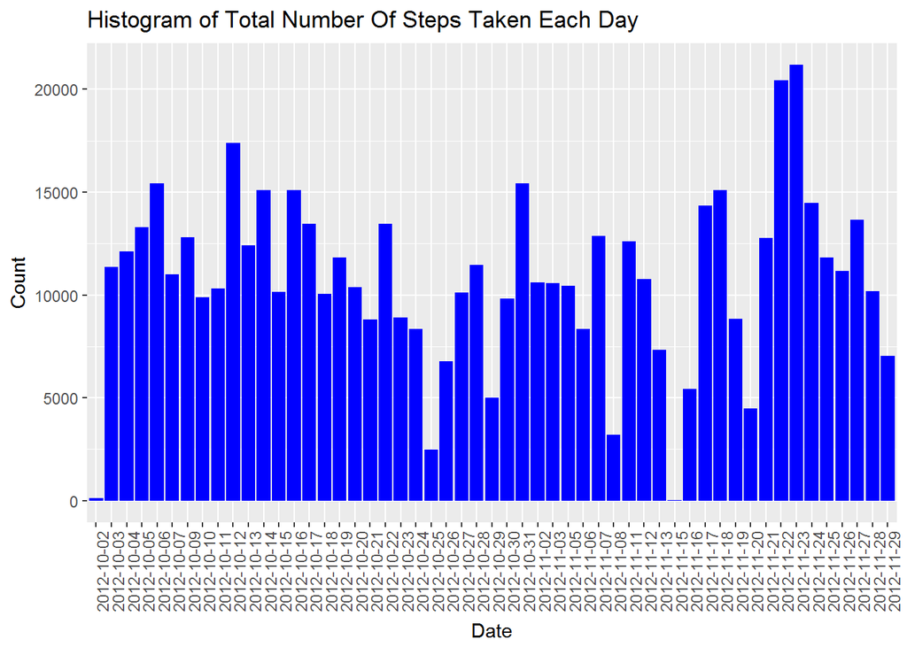

```r
dt<-aggregate(newdata$steps,list(date=newdata$date),sum)
ggplot(dt,aes(date,x))+geom_bar(stat="Identity",fill = "blue")+ylab("Count")+xlab("Date")+ggtitle("Histogram of Total Number Of Steps Taken Each Day")+theme(axis.text.x=element_text(angle=90, hjust=1))
```

```r
data1<-newdata[newdata$steps!=0,]
meansteps<-data.frame(aggregate(data1$steps,list(date=data1$date),mean))
mediansteps<-aggregate(data1$steps,list(date=data1$date),median)
names(meansteps)<-c("Date","Meansteps")
names(mediansteps)<-c("Date","Mediansteps")
print("Mean Number Of Steps Taken Each Day")
```

```
## [1] "Mean Number Of Steps Taken Each Day"
```

```r
print(meansteps)
```

```
##          Date Meansteps
## 1  2012-10-02  63.00000
## 2  2012-10-03 140.14815
## 3  2012-10-04 121.16000
## 4  2012-10-05 154.58140
## 5  2012-10-06 145.47170
## 6  2012-10-07 101.99074
## 7  2012-10-09 134.85263
## 8  2012-10-10  95.19231
## 9  2012-10-11 137.38667
## 10 2012-10-12 156.59459
## 11 2012-10-13 119.48077
## 12 2012-10-14 160.61702
## 13 2012-10-15 131.67532
## 14 2012-10-16 157.12500
```

[output cut: 39 more lines]

```r
print("Median Number of Steps Taken Each Day")
```

```
## [1] "Median Number of Steps Taken Each Day"
```

```r
print(mediansteps)
```

```
##          Date Mediansteps
## 1  2012-10-02        63.0
## 2  2012-10-03        61.0
## 3  2012-10-04        56.5
## 4  2012-10-05        66.0
## 5  2012-10-06        67.0
## 6  2012-10-07        52.5
## 7  2012-10-09        48.0
## 8  2012-10-10        56.5
## 9  2012-10-11        35.0
## 10 2012-10-12        46.0
## 11 2012-10-13        45.5
## 12 2012-10-14        60.5
## 13 2012-10-15        54.0
## 14 2012-10-16        64.0
```

[output cut: 39 more lines]

4. Time Series Plot Of Average Number Of Steps Taken Each Day

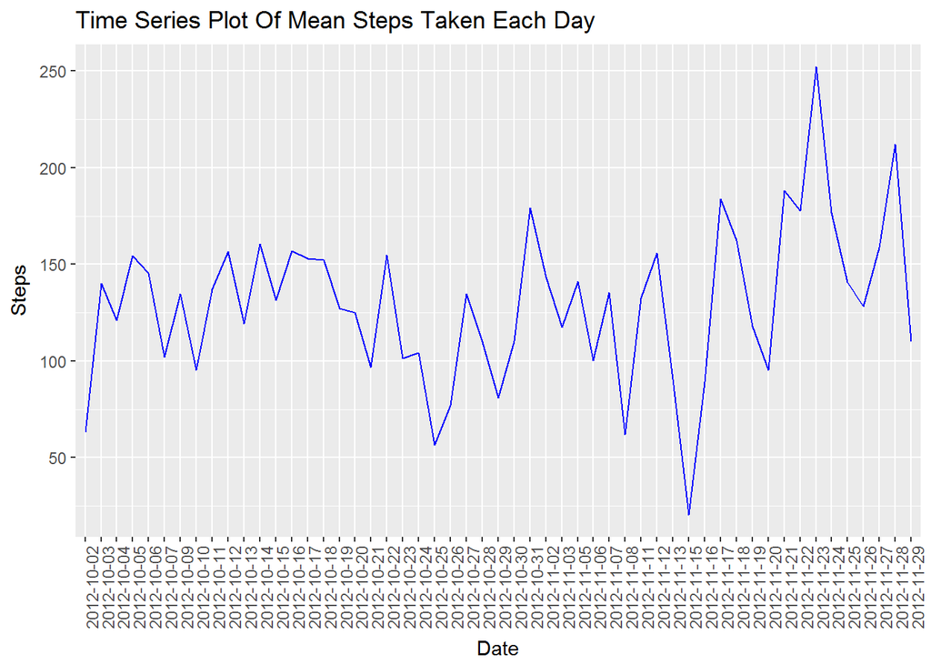

```r
ggplot(meansteps,aes(Date,Meansteps,group=1))+geom_line(colour="Blue")+ylab("Steps")+xlab("Date")+ggtitle("Time Series Plot Of Mean Steps Taken Each Day")+theme(axis.text.x=element_text(angle=90, hjust=1))
```

```r
meanvalue<-tapply(newdata$steps,newdata$interval,mean)
print(head(meanvalue))
```

```
##         0         5        10        15        20        25
## 1.7169811 0.3396226 0.1320755 0.1509434 0.0754717 2.0943396
```

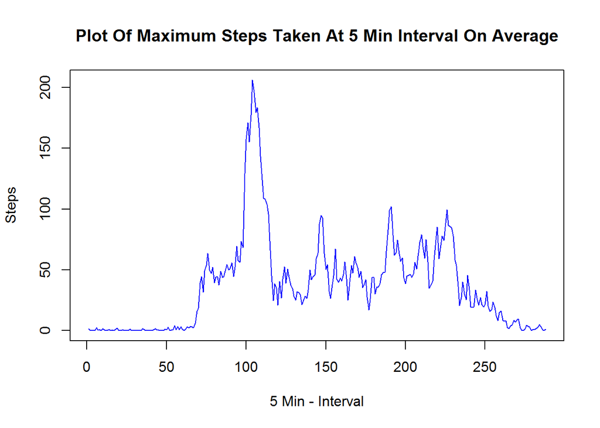

```r
plot(meanvalue,type="l",col="Blue",ylab="Steps",xlab="5 Min - Interval", main= " Plot Of Maximum Steps Taken At 5 Min Interval On Average ")
```

6. Code For Imputing Missing Values

```r
library(mice)
md.pattern(data)
```

```
##       date interval steps
## 15264    1        1     1    0
##  2304    1        1     0    1
##          0        0  2304 2304
```

```r
summary(data)
```

```
##      steps                date          interval
##  Min.   :  0.00   2012-10-01:  288   Min.   :   0.0
##  1st Qu.:  0.00   2012-10-02:  288   1st Qu.: 588.8
##  Median :  0.00   2012-10-03:  288   Median :1177.5
##  Mean   : 37.38   2012-10-04:  288   Mean   :1177.5
##  3rd Qu.: 12.00   2012-10-05:  288   3rd Qu.:1766.2
##  Max.   :806.00   2012-10-06:  288   Max.   :2355.0
##  NA's   :2304     (Other)   :15840
```

```r
impute_data<-mice(data,m=5,maxit=50,method='pmm',seed=500)
summary(impute_data)
```

```
## Multiply imputed data set
## Call:
## mice(data = data, m = 5, method = "pmm", maxit = 50, seed = 500)
## Number of multiple imputations:  5
## Missing cells per column:
##    steps     date interval
##     2304        0        0
## Imputation methods:
##    steps     date interval
##    "pmm"    "pmm"    "pmm"
## VisitSequence:
## steps
##     1
## PredictorMatrix:
##          steps date interval
## steps        0    1        1
## date         0    0        0
## interval     0    0        0
## Random generator seed value:  500
```

```r
impute_data$imp$steps
```

```
##         1   2   3   4   5
## 1       0  33   0  84 179
## 2       0   0  25   0   0
## 3       0   0   0   0   0
## 4       0  19   0   0   0
## 5       0   0  23 189   0
## 6       0  73  23   0   0
## 7       0   0   0   0 111
## 8       0   0   0   0   0
## 9       0 415   0   0   0
## 10      0 356   0   0   0
## 11     14 275  19   0 117
## 12      0   0   0   0   0
## 13    163   0   0   0   0
## 14      0   0   0  70   0
```

[output cut: 2290 more lines]

```r
completeData<-complete(impute_data,2)
head(completeData)
```

```
##   steps       date interval
## 1    33 2012-10-01        0
## 2     0 2012-10-01        5
## 3     0 2012-10-01       10
## 4    19 2012-10-01       15
## 5     0 2012-10-01       20
## 6    73 2012-10-01       25
```

7. Histogram of the total number of steps taken each day after missing values are imputed

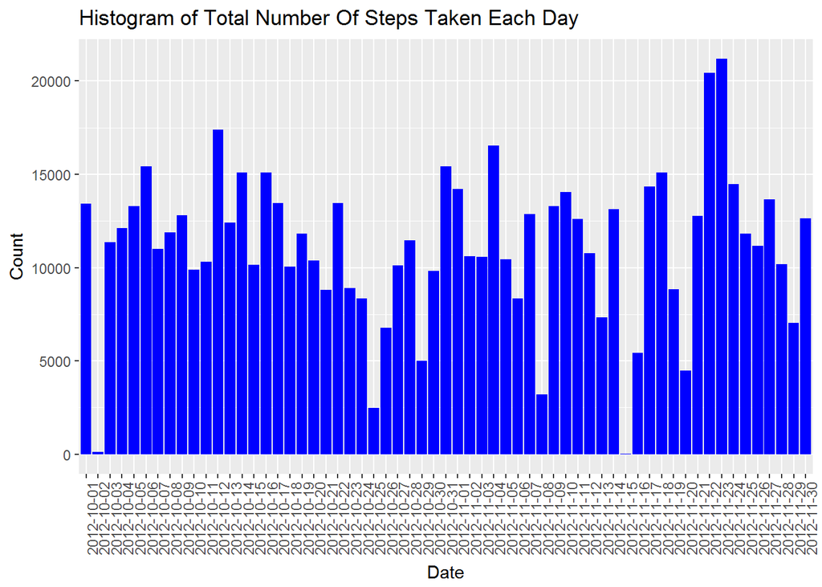

```r
dt<-aggregate(completeData$steps,list(date=completeData$date),sum)
ggplot(dt,aes(date,x))+geom_bar(stat="Identity",fill = "blue")+ylab("Count")+xlab("Date")+ggtitle("Histogram of Total Number Of Steps Taken Each Day")+theme(axis.text.x=element_text(angle=90, hjust=1))
```

8. Panel plot comparing the average number of steps taken per 5-minute interval across weekdays and weekends

```r
library(lattice)
```

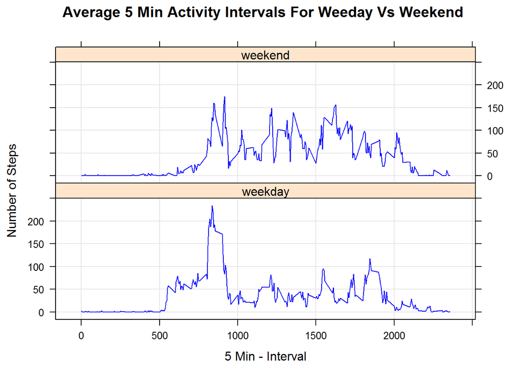

```r
newdata$day<-"weekday"
newdata$day[weekdays(as.Date(newdata$date),abb=T) %in% c("Sat","Sun")]<-"weekend"
wdata<-aggregate(steps~interval+day, data=newdata,FUN="mean")

xyplot(steps~interval | day, data = wdata, type="l",grid=T,layout=c(1,2), col="Blue",ylab="Number of Steps",xlab="5 Min - Interval", main= " Average 5 Min Activity Intervals For Weeday Vs Weekend")
```